# 🛒 E-Commerce Delivery Performance & Customer Retention Analysis

### Olist Brazil | 100K+ Orders | Python | 2016–2018

> Olist scaled revenue 20× in two years. This analysis identifies the single operational chain driving that growth — and the exact point where it breaks.

## Setup — Load & Clean All Data

All loading, cleaning, and feature engineering is handled by `src/data_processing.py`. The notebook receives clean, analysis-ready DataFrames from three function calls below.

```
✅ All tables loaded and cleaned successfully.
   customers:            (99441, 5)
   orders:               (99441, 8)
   order_items:          (112650, 7)
   payments:             (103886, 5)
   reviews:              (99224, 5)
   products:             (32949, 10)
   sellers:              (3095, 4)
   geolocation:          (1000163, 5)
   category_translation: (71, 2)
```

```
✅ Delivery metrics built successfully.
   Delivered orders   : 96,478
   Avg delivery time  : 12.09 days
   Late delivery rate : 6.77%
```

```
🔄 Building geo_agg from raw data (1M+ rows) — this runs once...
   Duplicates removed : 261,831 rows
   Rows remaining     : 738,332
   Unique zip prefixes : 19,015
   ✅ Cache saved to: data/processed/geo_agg.parquet
✅ geo_agg built successfully.
```

## **Outlier Analysis on potential tables**

### i. Order items

|  | price | freight_value |
| --- | --- | --- |
| count | 112650.000000 | 112650.000000 |
| mean | 120.653739 | 19.990320 |
| std | 183.633928 | 15.806405 |
| min | 0.850000 | 0.000000 |
| 25% | 39.900000 | 13.080000 |
| 50% | 74.990000 | 16.260000 |
| 75% | 134.900000 | 21.150000 |
| max | 6735.000000 | 409.680000 |

**Freight Distribution:** Shipping costs are relatively standardized — median freight is modest, with limited extreme cases, suggesting Olist's logistics are cost-controlled.

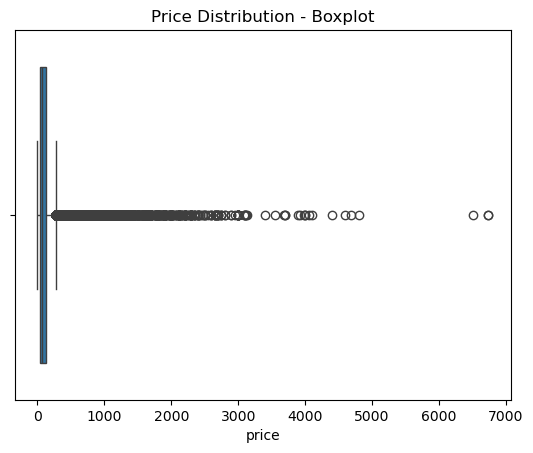

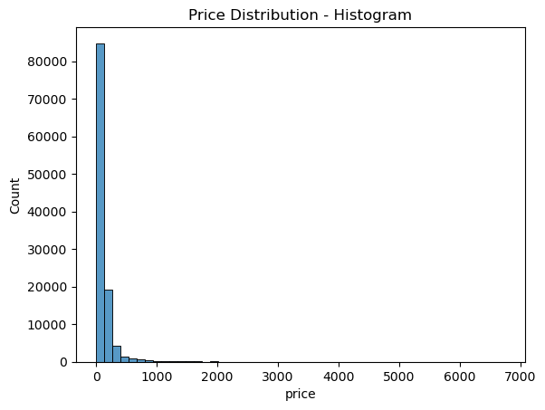

Boxplot Interpretation

- The box (IQR) is compressed near the left (low prices)
- Many visible outliers to the right
- Extreme values reaching ~6000–7000

Histogram Interpretation:

- Massive concentration of prices in the low range.
- Rapid drop-off as price increases
- Very long right tail extending up to ~7000
- Very few extremely high-priced items

```
Number of Price Outliers: 8427
```

- In a normal distribution, outliers should be very small (<1%). Here, 7.5% or 8427 being flagged confirms that IQR is capturing skew, not data errors. Removing price outliers would distort business reality

#### Overall Insight

- Olist operates mainly in the affordable mass-market segment, but includes a smaller premium tier that significantly influences revenue metrics. Shipping represents a meaningful share of product cost. Outliers reflect real business structure rather than data issues and should be retained for accurate financial analysis.

### ii. Payments

- Payment_value affects revenue KPIs
- Installments reflect customer financial behavior.

|  | payment_value | payment_installments |
| --- | --- | --- |
| count | 103886.000000 | 103886.000000 |
| mean | 154.100380 | 2.853349 |
| std | 217.494064 | 2.687051 |
| min | 0.000000 | 0.000000 |
| 25% | 56.790000 | 1.000000 |
| 50% | 100.000000 | 1.000000 |
| 75% | 171.837500 | 4.000000 |
| max | 13664.080000 | 24.000000 |

```
Payment Value Outliers: 7981
```

#### Revenue Structure

- Payment values are:
- Strongly right-skewed
- Concentrated in low-to-mid range
- Influenced by a small number of very high payments

#### Customer Payment Behavior

- Majority prefer single-payment transactions
- Installments up to 4 are common
- Long installment plans (12–24) indicate structured credit options

#### Insights

- Most customers pay in a single installment, but installment plans up to 4 payments are common.
- The presence of long installment plans (up to 24) reflects structured credit behavior rather than anomalies.
- Outliers represent real high-value transactions and should not be removed without business justification.

### iii. Orders

|  | delivery_days | estimated_delivery_days | delay_days |
| --- | --- | --- | --- |
| count | 96476.000000 | 99441.000000 | 96476.000000 |
| mean | 12.094086 | 23.403958 | -11.876881 |
| std | 9.551746 | 8.829562 | 10.183854 |
| min | 0.000000 | 1.000000 | -147.000000 |
| 25% | 6.000000 | 18.000000 | -17.000000 |
| 50% | 10.000000 | 23.000000 | -12.000000 |
| 75% | 15.000000 | 28.000000 | -7.000000 |
| max | 209.000000 | 155.000000 | 188.000000 |

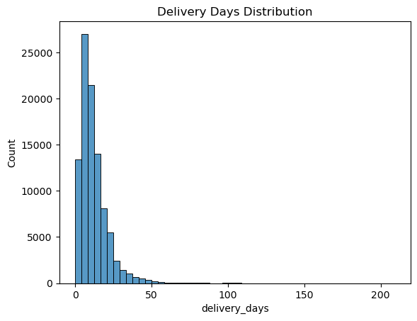

```
Delivery Time Outliers: 5025
Upper Bound: 28.5
```

```
Percentage of Late Deliveries: 6.57 %
```

#### Overall Interpretation

- Delivery times are right-skewed, with most orders delivered in 10 days (median) despite an estimated 23 days, meaning deliveries are typically much earlier than promised. Only 6.57% of orders are late, and about 5% exceed the 28.5-day outlier threshold, forming a long but limited extreme tail.

#### Final Insight

- The company uses a highly conservative delivery estimate strategy, resulting in strong on-time performance and customer expectation management, with only a small proportion of extreme delays requiring further investigation.

## **EXPLORATORY DATA ANALYSIS**

### **I. Sales Overview**

**Business Question:** What is the realized revenue base, and is Olist's growth driven by elite high-value orders or broad volume across mid-range transactions?

|  | order_id | payment_value | order_purchase_timestamp |
| --- | --- | --- | --- |
| 0 | 00010242fe8c5a6d1ba2dd792cb16214 | 72.19 | 2017-09-13 08:59:02 |
| 1 | 00018f77f2f0320c557190d7a144bdd3 | 259.83 | 2017-04-26 10:53:06 |
| 2 | 000229ec398224ef6ca0657da4fc703e | 216.87 | 2018-01-14 14:33:31 |
| 3 | 00024acbcdf0a6daa1e931b038114c75 | 25.78 | 2018-08-08 10:00:35 |
| 4 | 00042b26cf59d7ce69dfabb4e55b4fd9 | 218.04 | 2017-02-04 13:57:51 |

#### Revenue Base Validated: 96K Delivered Orders, BRL 15.4M Realized

- Data successfully aggregated at order level — 1 row = 1 order, no installment duplication.
- Revenue is correctly summed per order; purchase timestamp preserved for time analysis.

```
Total Revenue:       BRL 15,422,461.77
Total Orders:              96,477
Average Order Value: BRL       159.86

count    96477.00
mean       159.86
std        218.81
min          9.59
25%         61.88
50%        105.28
75%        176.33
max      13664.08
Name: payment_value, dtype: float64
```

#### AOV of BRL 160 Confirms Multi-Item Orders — Not a Low-Ticket Business

- BRL 15.4M revenue from 96K delivered orders places AOV at 159.86 — above median product price, confirming orders typically contain multiple items and freight contributes to final value.
- High std (217 BRL) relative to mean (160 BRL) signals a right-skewed distribution: the mean is being pulled up by a minority of high-value transactions. Median is the more reliable central tendency measure here.

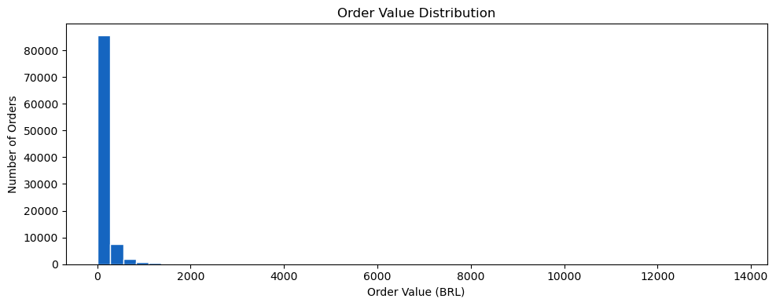

- The histogram is strongly right-skewed which means:
  - Most orders are low-to-mid value.
  - A small number of orders are very high value.
- This confirms that mean AOV (159.86) is influenced by high-value orders.

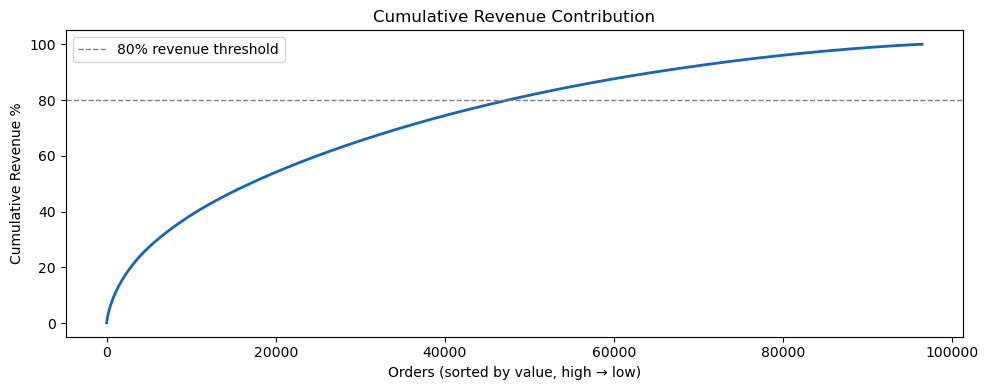

```
► Top 49.2% of orders generate 80% of revenue
  → Revenue is volume-driven: requires the majority of orders to reach 80% threshold
```

#### Revenue Is Volume-Driven: No Elite-Order Concentration

- The curve rises steadily rather than steeply — revenue is distributed across a broad base of orders, not concentrated in a small premium segment.
- The gradual flattening confirms a long tail of lower-value orders that collectively account for significant revenue share.
- **Pareto result printed above** quantifies this precisely.

### **II. Time Analysis**

**Business Question:** Is Olist's revenue growth sustainable, or is it concentrated in a few volatile months that create operational and inventory risk?

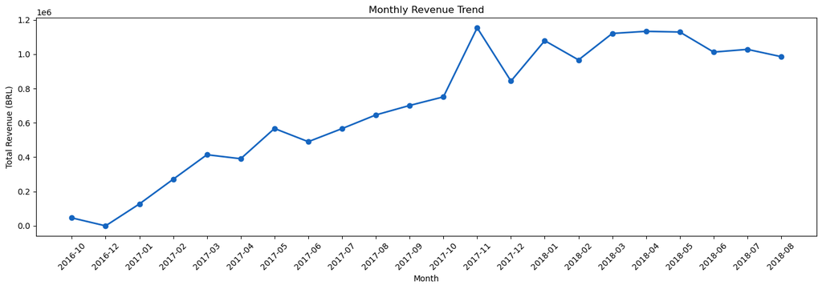

```
=== Monthly Revenue ===
   order_month  payment_value
0      2016-10       46566.71
1      2016-12          19.62
2      2017-01      127545.67
3      2017-02      271298.65
4      2017-03      414369.39
5      2017-04      390952.18
6      2017-05      567066.73
7      2017-06      490225.60
8      2017-07      566403.93
9      2017-08      646000.61
10     2017-09      701169.99
11     2017-10      751140.27
12     2017-11     1153528.05
13     2017-12      843199.17
14     2018-01     1078606.86
15     2018-02      966510.88
16     2018-03     1120678.00
17     2018-04     1132933.95
18     2018-05     1128836.69
19     2018-06     1012090.68
20     2018-07     1027903.86
21     2018-08      985414.28
```

#### Monthly Revenue Trend

- Revenue started very low in late 2016, showing the platform was in its early stage.
- Strong and consistent growth throughout 2017, from ~127K in January to ~751K by October.
- A sharp spike in 2017-11 (1.15M BRL) — the highest month in the dataset.
- A drop in 2017-12 (~843K), followed by recovery and stabilization in 2018 between ~966K–1.13M BRL.
- Slight softening in mid-2018 (Jun–Aug), though this may reflect dataset truncation rather than a real decline.

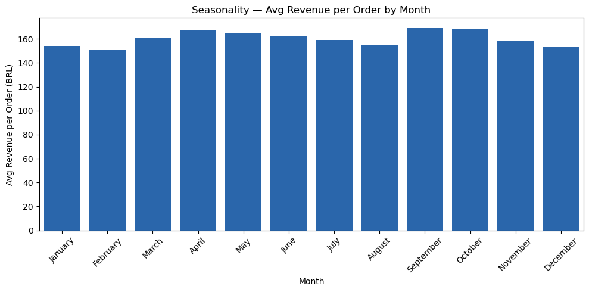

```
=== Seasonality Averages ===
   month_label  payment_value
0      January     154.259180
1     February     150.805255
2        March     160.754780
3        April     167.441614
4          May     164.730784
5         June     162.693987
6         July     158.938071
7       August     154.724477
8    September     168.956624
9      October     168.186165
10    November     158.256009
11    December     152.923248
```

#### Seasonality: Avg Revenue per Order

- The range is very narrow: 150.8 (February) to 169.0 (September) — only an ~18 BRL spread across the entire year.
- September and October have the highest average order values (168–169 BRL).
- February and December are the lowest (150–153 BRL).
- Seasonal variation in spend per order is minimal.

#### Summary Insight: Time Analysis

Olist's revenue growth was driven by increasing order volume, not by customers spending more per order. Average order value is remarkably stable year-round (±18 BRL). The business scaled ~20x from launch to plateau in under two years, with 2017-11 standing out as the single peak month. By 2018, revenue stabilized at a new high plateau of ~1M+ BRL/month.

### **III. Product Analysis**

**Business Question:** Which categories should receive prioritized inventory, marketing spend, and logistics investment — based on revenue efficiency vs. volume?

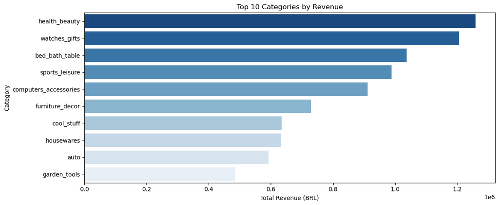

```
=== Top 10 by Revenue ===
                category       price
0          health_beauty  1258681.34
1          watches_gifts  1205005.68
2         bed_bath_table  1036988.68
3         sports_leisure   988048.97
4  computers_accessories   911954.32
5        furniture_decor   729762.49
6             cool_stuff   635290.85
7             housewares   632248.66
8                   auto   592720.11
9           garden_tools   485256.46
```

#### health_beauty Leads Revenue at BRL 1.26M — Pricing Power Drives the Top 2

- **health_beauty** (1.26M) and **watches_gifts** (1.21M) lead by a significant margin.
- **bed_bath_table**, **sports_leisure**, and **computers_accessories** form a solid mid-tier (900K–1.04M BRL).

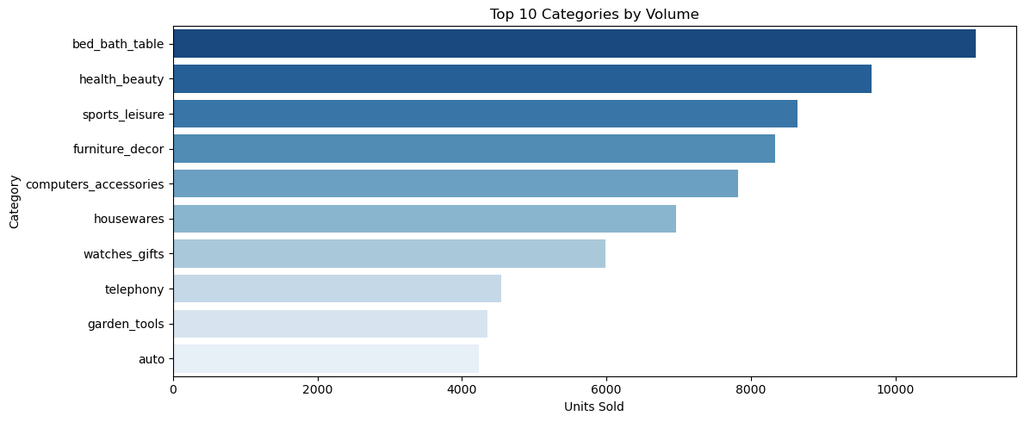

```
=== Top 10 by Volume ===
                category  units_sold
0         bed_bath_table       11115
1          health_beauty        9670
2         sports_leisure        8641
3        furniture_decor        8334
4  computers_accessories        7827
5             housewares        6964
6          watches_gifts        5991
7              telephony        4545
8           garden_tools        4347
9                   auto        4235
```

#### bed_bath_table Leads Volume at 11,115 Units — watches_gifts Reveals Pricing Power Gap

- **bed_bath_table** leads volume (11,115 units) but ranks 3rd in revenue — high turnover, lower price per unit.
- **health_beauty** (9,670 units) is the only category in the top 2 for both revenue and volume — uniquely balanced.
- **watches_gifts** ranks 2nd in revenue but 7th in volume — generates outsized revenue from fewer transactions.

### Summary Insight — Product Analysis

Two distinct category archetypes coexist on the platform: **revenue-efficient** categories (watches_gifts: high price, low volume) and **volume-driven** categories (bed_bath_table: high volume, lower margin). health_beauty is the standout — it is the only category ranking top-2 in both dimensions.

**✅ Recommendation:** Prioritize health_beauty for inventory depth, promotional spend, and seller acquisition.

### **IV. Payment Analysis**

**Business Question:** Does the current payment infrastructure serve all customer segments, and are installment structures aligned with observed purchasing behavior?

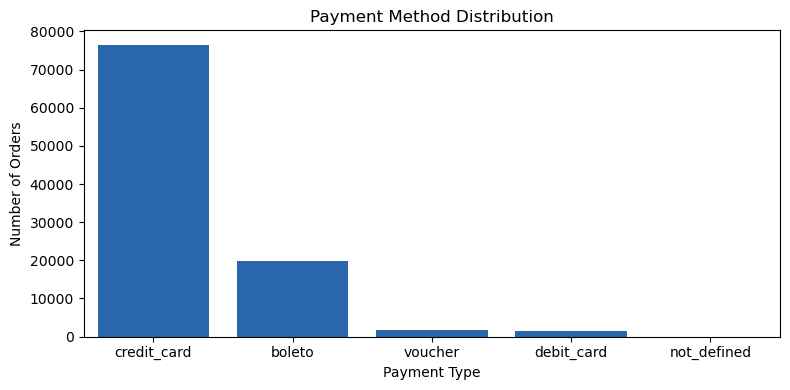

```
=== Payment Methods ===
  payment_type  order_count
0  credit_card        76476
1       boleto        19783
2      voucher         1621
3   debit_card         1477
4  not_defined            3
```

#### Credit Card Captures 77% of Transactions — Boleto Retains a Structurally Distinct 20%

- **Credit card dominates** with 76,476 orders (~77%) — the primary revenue channel.
- **Boleto accounts for 20% (19,783 orders)** — not a marginal segment. Boleto is a Brazil-specific bank-slip payment used by customers who are unbanked or prefer cash-based transactions. Removing it would exclude 1 in 5 customers.

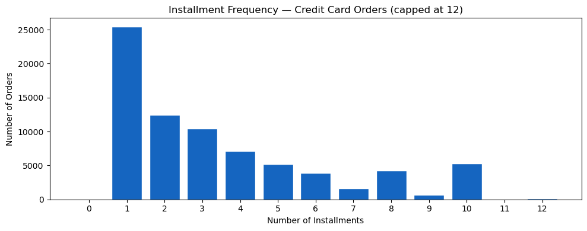

```
=== Installment Distribution (Credit Card) ===
    payment_installments  order_count
0                      0            2
1                      1        25455
2                      2        12413
3                      3        10461
4                      4         7098
5                      5         5239
6                      6         3920
7                      7         1626
8                      8         4268
9                      9          644
10                    10         5328
11                    11           23
12                    12          133
13                    13           16
14                    14           15
15                    15           74
16                    16            5
17                    17            8
18                    18           27
19                    20           17
20                    21            3
21                    22            1
22                    23            1
23                    24           18
```

#### Installment Behavior (Credit Card Only)

- 1 installment is by far the most common (25,455 orders) — most customers prefer to pay in full.
- Installments 2–6 show a steady decline, reflecting a natural drop-off as plans get longer.
- Notable spikes at 8 (4,268) and 10 (5,328) — specific plan options actively offered by the platform.

#### Summary Insight — Payment Analysis

Credit card is the overwhelmingly preferred channel at 77%. The 8- and 10-installment spikes represent engineered purchase-enabling tools for higher-value transactions. Boleto's 20% share is structurally significant, not incidental.

**✅ Recommendation:** Retain boleto as a first-class payment option.

### **V. Customer Satisfaction**

**Business Question:** What operational variable most directly predicts a 1-star review — and how large is the measurable gap between satisfied and dissatisfied customers?

```
=== Review Score Distribution ===
   score  order_count  percentage
0      1         9409        9.76
1      2         2941        3.05
2      3         7962        8.26
3      4        18987       19.70
4      5        57060       59.22

=== Avg Delivery Days by Review Score ===
   review_score  delivery_days
0             1          20.85
1             2          16.19
2             3          13.80
3             4          11.85
4             5          10.22
```

#### 79% Positive Rate Masks a Polarization Problem: Score 1 Is 3× Higher Than Score 2

- **Score 5 dominates at 59.22%** — strong base satisfaction.
- **Scores 4+5 combined: 78.92%** — the majority of customers are satisfied.
- **Score 1 at 9.76% is disproportionately high** relative to score 2 (3.05%) and score 3 (8.26%). When the experience breaks down, customers go straight to the floor.
- The 9.76% score-1 rate is the primary retention risk metric in this dataset.

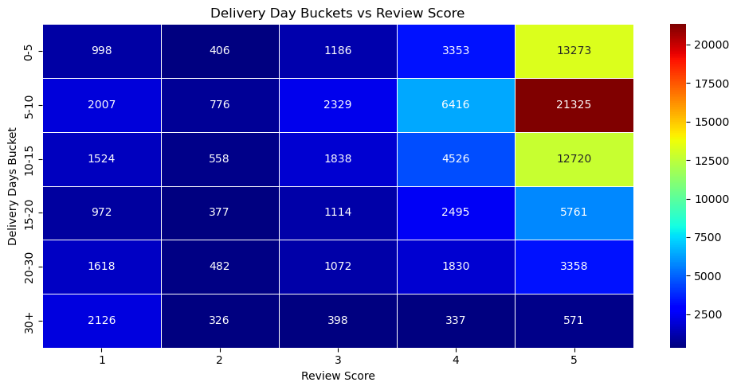

#### 2× Delivery Gap: Score-1 Customers Waited Twice as Long as Score-5

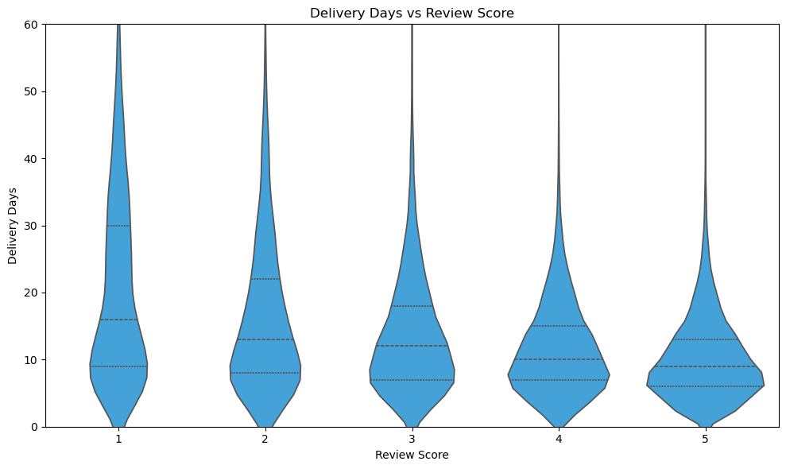

#### Summary Insight — Customer Satisfaction

Delivery speed is the primary driver of review score. The violin analysis adds a critical nuance — it is not only about speed, it is about consistency.

**✅ Recommendation:** Establish a delivery consistency SLA: flag any order with delivery variance >2 standard deviations from the mean as an operational alert — before the review is submitted, not after.

### **VI. Delivery Performance**

**Business Question:** Is the platform's delivery reliability improving over time, and where is operational risk most concentrated?

|  | delivery_days | delay_days |
| --- | --- | --- |
| count | 96470.00 | 96470.00 |
| mean | 12.09 | -11.88 |
| std | 9.55 | 10.18 |
| min | 0.00 | -147.00 |
| 25% | 6.00 | -17.00 |
| 50% | 10.00 | -12.00 |
| 75% | 15.00 | -7.00 |
| max | 209.00 | 188.00 |

```
Average Delivery Time: 12.09 days
Late Delivery Percentage: 6.77 %
```

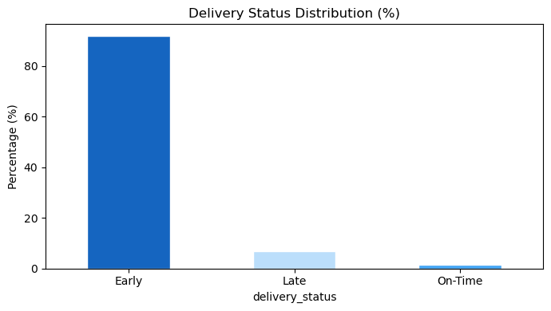

```
delivery_status
Early      91.89
Late        6.77
On-Time     1.34
Name: proportion, dtype: float64
```

#### 92% Early Deliveries Is a Strategy, Not Luck — But Only 1% Hit the Estimate Exactly

- **91.89% of orders arrived Early** — direct result of conservative delivery estimates set ~12 days beyond actual delivery time.
- **6.77% Late** — small but operationally significant; late deliveries are the primary driver of 1-star reviews.
- **1.34% On-Time** — almost no orders hit the estimated date exactly, confirming the estimate is a buffer mechanism, not a precision target.

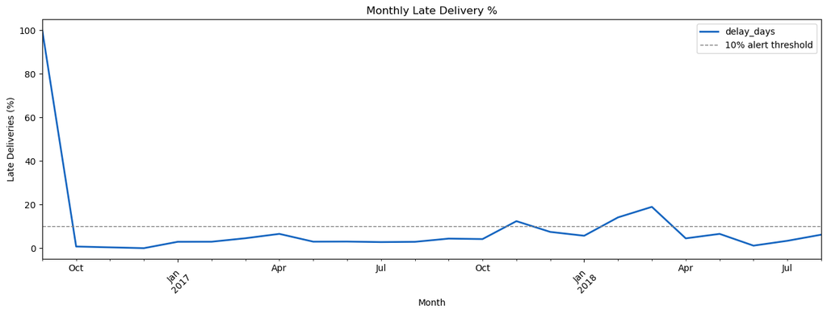

```
=== Monthly Late Delivery % ===
purchase_month
2016-09    100.00
2016-10      0.75
2016-12      0.00
2017-01      2.93
2017-02      2.96
2017-03      4.56
2017-04      6.56
2017-05      2.99
2017-06      3.03
2017-07      2.79
2017-08      2.91
2017-09      4.39
2017-10      4.18
2017-11     12.40
2017-12      7.46
2018-01      5.70
2018-02     14.13
2018-03     18.96
2018-04      4.50
2018-05      6.56
2018-06      1.16
2018-07      3.38
2018-08      6.19
Freq: M
```

#### 2018 Q1 Is the Only Structural Risk Event — Late Rate Peaked at 19% in March

- **2016-09 at 100%** is a data artifact — the platform had just launched with near-zero order volume.
- **2017: late rate held below 7%** for most months — the conservative estimation strategy was working.
- **2017-11 spike to 12.4%** followed by recovery — consistent with a single high-volume month straining logistics capacity.
- **2018-02 through 2018-03 peaked at 19%** — the only sustained operational failure in the dataset.
- **2018-04 onwards: recovery to below 7%** — the platform self-corrected.

# What the Data Is Really Saying

Olist scaled revenue 20× in two years without meaningfully increasing what customers spend per order — every unit of growth came from acquiring more customers, not extracting more from existing ones. That model is sustainable only as long as the customer experience holds. The data reveals a single operational chain connecting everything:

> **Delivery speed → Satisfaction → Review score → Repeat purchase → Revenue**

**health_beauty's dominance** across both revenue and volume, **credit card's 77% share**, and the conservative delivery estimation strategy all confirm the same thing: Olist has found a formula that works at scale. The analysis quantifies the cost of breaking it.

[output not shown]

The single most important operational metric in this business is not revenue, AOV, or category mix. **It is the monthly late delivery rate.** Everything else follows from it.